# Évaluation du modèle Camembert NER

Ce notebook présente l'évaluation du modèle NER Camembert pour la détection des entités suivantes :

- **O** : Aucun intérêt, non lié à une ville.
- **B-DEP** : Début d'une ville de départ.
- **B-ARR** : Début d'une ville de destination.
- **I-DEP** : Continuation d'une ville de départ.
- **I-ARR** : Continuation d'une ville de destination.

## Visualisation des métriques de performance

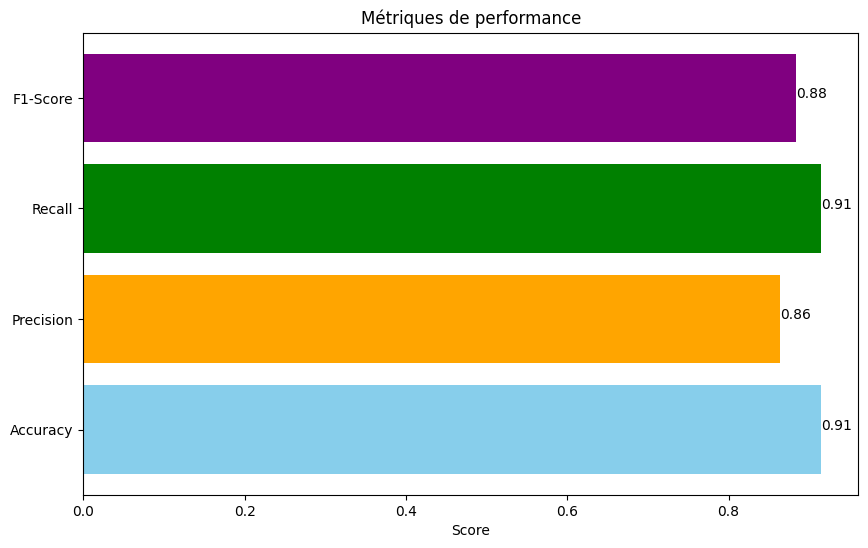

## Matrice de confusion

La matrice de confusion compare les prédictions du modèle avec les étiquettes réelles :

- Les **lignes** correspondent aux étiquettes réelles (ce que le modèle devait prédire).
- Les **colonnes** correspondent aux étiquettes prédites (ce que le modèle a réellement prédit).
- La diagonale principale montre les prédictions correctes.

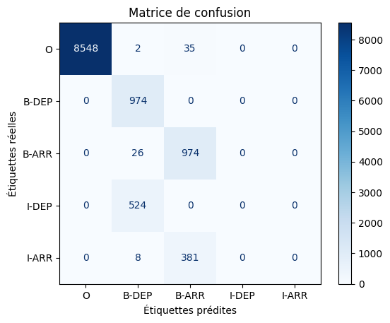

## Distribution des classes

Ce graphique montre la répartition des classes dans les étiquettes réelles et prédites :

- **Axe X** : Les différentes classes (`O`, `B-DEP`, etc.).
- **Axe Y** : Le nombre de tokens dans chaque classe.
- Les barres permettent de comparer la répartition entre les étiquettes réelles et prédites.

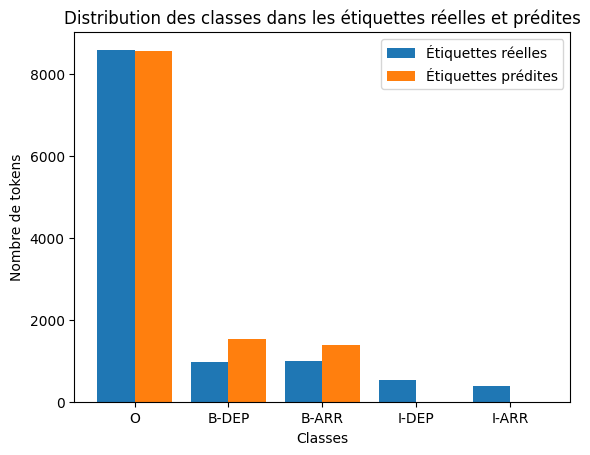

## F1-Score par classe

Le F1-score par classe combine précision et rappel pour chaque classe :

- **Axe X** : Les différentes classes (`O`, `B-DEP`, etc.).
- **Axe Y** : Le score F1 (entre 0 et 1).
- Plus le score F1 est proche de 1, meilleures sont les prédictions pour cette classe.

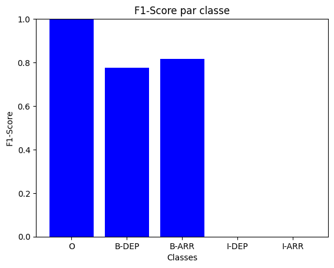

## Courbe ROC

La courbe ROC évalue la capacité du modèle à discriminer entre les classes.

- **Axe X** : Taux de faux positifs (FPR).
- **Axe Y** : Taux de vrais positifs (TPR).
- Une courbe proche de la diagonale indique une mauvaise séparation des classes.
- L'AUC (Area Under Curve) mesure l'efficacité globale (1 = parfait, 0.5 = aléatoire).

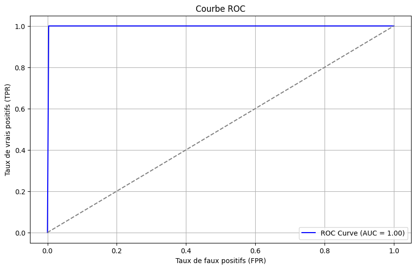

## Distribution des longueurs des phrases

Ce graphique montre la distribution des longueurs des phrases dans le dataset.

- **Axe X** : Longueur des phrases (en tokens).
- **Axe Y** : Nombre de phrases ayant cette longueur.
- Ce graphique permet de vérifier si les performances du modèle varient en fonction de la complexité (longueur) des phrases.

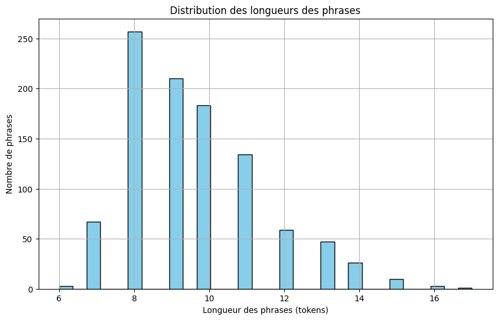